# Property Tax Bill Explainer

Get your report by email:

## What are property taxes?

Property tax is owed by property owners annually, for both residential and commercial properties.

These liabilities are decided per **Property Parcel**, and each parcel is uniquely identifiable with a 14-digit **Property Index Number** or **PIN**.

Every **PIN** belongs to multiple tax districts (local government bodies), that each require funding for purposes like operating schools, libraries, parks etc.

The Cook County Assessor’s Office, the State, and county taxing districts (schools, parks, etc.) work together to calculate fair property taxes for residents.

Each year you receive one tax bill that is split across two payments. The first installment is due by March 1st and will be 55% of last year’s tax bill. The second installment is sent around June 30 and is for the remaining taxes due.

## Your Property

| PIN | 17221070890000 |
| --- | --- |
| Market Value | $195,540 |
| Class | Multi-Family - Special rental structure |
| Last Assessment Year | 2021 |
| Total Exemptions | 0 |
| Total Exemptions Amount | $0 |

## Why Did my Property Tax Bill Change?

The tax bill for **Parcel (17-22-107-089-0000)** was approximately $3,431 in 2021 and $4,139 in 2023, resulting in an **increase** of **$708**. This change can be broken down into two main components as shown below. The largest change in your bill was due to **your property’s share of all residential properties changing**.

Your tax bill increased by approximately **$298** due to the increase in your taxing districts’ levies. This is the change in the tax bill outside your control, is the same for everyone, and refers to the increase in the cost of providing services.

Your tax levy increased and your assessed value increased, while your combined tax bill increased.

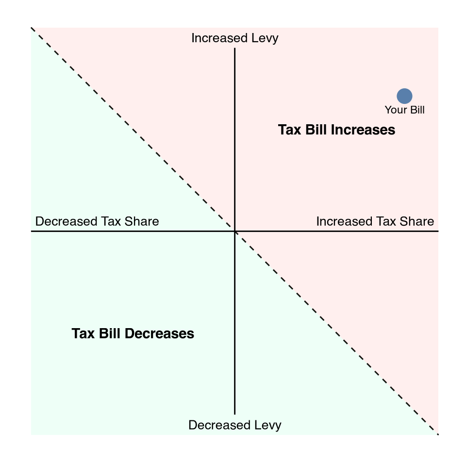

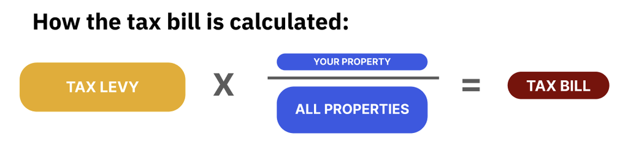

Property tax bills are calculated based on the **Tax Levy** and the value of your property. First, the government determines the **Tax Levy**, or total amount of taxes imposed by the government. This levy is then divided among all property owners in the area. Your share of this levy depends on **how much your property is worth compared to the total value of all properties**.

Your final tax bill reflects your property’s **share of the total taxable value** in the area, meaning you contribute to the Tax Levy in proportion to your property’s worth.

## How did your property’s change in price affect my bill?

This share is how much your property’s taxable value, or its Equalized Assessed Value, makes up of the the taxable value of all properties, called the Tax Base. The Tax Base is the combination of the taxable value of all residential and commercial properties.

**(A) Change from Exemptions**

**(B) Change from your Property’s Share of all Residential Properties**

**(C) Change from Commercial-Residential Ratio**

#### (A) Change from Exemptions

Your tax bill may have changed due to a change in your exemptions. Property tax exemptions are savings that contribute to lowering a homeowner’s property tax bill. Learn more about exemptions, including how to apply, at the [Cook County Assessor’s Office’s website](https://www.cookcountyaa.gov/property-tax-exemptions).

Your exemptions did not change between 2021 and 2023 so your tax bill did not change.

**Change By Exemption**

NO CHANGE AND NO EXEMPTIONS

#### (B) Change from your Property’s Share of all Residential Properties

A second reason your tax bill changed is due to the change in your property’s taxable value compared to all other properties in your area. Your property’s taxable value **increased** by **15.47%** from $51,079 to $58,981. If the estimated market value of your home is significantly more than what you believe your home could sell for in the current real estate market, you should [file an appeal with the Cook County Assessor’s Office](https://www.cookcountyaa.gov/appeal-your-assessment).

Your property’s fair market value (as determined by the Cook County Assessor’s Office) is $196K. This is used to calculate your property’s taxable value, called the Equalized Assessed Value (EAV). This year, your EAV was $58,981. See Appendix A for more details about this calculation.

More important than how this specific property’s value changed is how much it changed value compared to all other properties in your area. From 2021 to 2023 your property’s taxable value increased by more than other properties in your area. This caused your tax bill to **increase** by **$412**.

**Change by District**

|  | Change in Tax Amount |  |
| --- | --- | --- |
| Cook County | −$0.58 |  |
| Miscellaneous | $23.97 |  |
| Municipality/Township | $130.00 |  |
| School | $259.00 |  |
| Total Tax Owed | $412.39 | — |

See the breakdown of the change in EAV Residential Share for each district in Appendix D

#### (C) Change from Commercial-Residential Ratio

A third reason part your tax bill changed is due to how much **all** residential properties pay compared to **all** commercial properties. Commercial properties are more likely to decrease their assessment value through appeals, which shifts the tax burden more onto residential properties. The share that all residential properties paid in 2023 decreased caused your tax bill to **decrease** by **$32**

**Change by District**

|  | Change in Tax Amount |  |
| --- | --- | --- |
| Cook County | $5.04 |  |
| Miscellaneous | $1.10 |  |
| Municipality/Township | −$12.71 |  |
| School | −$25.33 |  |
| Total Tax Owed | −$31.90 | — |

See the breakdown of the change in Commercial Share for each district in Appendix D

## How did a change in the Tax Levy affect my bill?

Lastly, your tax bill may have also changed due to the change in the **Tax Levy**, or the total amount of taxes imposed by the government. The total **Tax Levy** for all tax districts for your property **increased** by **8.15%** between 2023 and 2021 which caused your tax bill to **increase** by **$298**.

**District wise changes in Levies**

|  | Change in Tax Amount |  |
| --- | --- | --- |
| Cook County | $9.85 |  |
| Miscellaneous | $14.38 |  |
| Municipality/Township | $50.62 |  |
| School | $223.41 |  |
| Total Tax Owed | $298.26 | — |

**Appendix A: Calculating Equalized Assessed Value**

First, start with the Fair Market Value and multiply by the Level of Assessment, which is 10% for all residential property, and the State Equalizer, a multiplier whose goal is to make property tax rates roughly equal across all IL counties. Both of these values are the same for all property owners in this area. After this, subtract your valid exemptions. [^1]

The resulting value is the Equalized Assessed Value.
$$\$196K \times 10.00\% \times 3.0163 = \$58,981$$
$$\$58,981 - \$0 = \$58,981$$

**Appendix B: Calculating a Single District’s Tax Bill**

Your property is in many tax districts.

[figure not shown]

Now, let’s look at the line item of the bill for **Parcel (17-22-107-089-0000)** in 2023 for **Board Of Education** -

|  | Tax District | Agency Tax Base | Agency Tax Levy | Agency Tax Rate | Final Tax Owed |
| --- | --- | --- | --- | --- | --- |
| School | Board Of Education | $99.65B | $3.82B | 3.83% | $2,258.38 |

For the purpose of operating **Board Of Education**, in 2023, it needs to collect **$4b** in order to provide services.

|  | Tax District | Agency Tax Base | Agency Tax Levy | Agency Tax Rate | Final Tax Owed |
| --- | --- | --- | --- | --- | --- |
| School | Board Of Education | $99.65B | $3.82B | 3.83% | $2,258.38 |

But where can **Board Of Education** raise the money from? From all the properties within the district boundaries!  
The total taxable value of all properties falling in **Board Of Education** make up its **tax base**. For 2023, this was **$100b**

|  | Tax District | Agency Tax Base | Agency Tax Levy | Agency Tax Rate | Final Tax Owed |
| --- | --- | --- | --- | --- | --- |
| School | Board Of Education | $99.65B | $3.82B | 3.83% | $2,258.38 |

The cost of services of **Board Of Education** is therefore divided amongst all the property owners, and **Board Of Education** sets its agency tax rate equal to:

$$\mathrm{{Levy \over Base} = Tax \hspace{0.1cm} rate}$$

Using real numbers, the tax rate equals:
$$\mathrm{\$4B \over \$100B} = 3.83\%$$

|  | Tax District | Agency Tax Base | Agency Tax Levy | Agency Tax Rate | Final Tax Owed |
| --- | --- | --- | --- | --- | --- |
| School | Board Of Education | $99.65B | $3.82B | 3.83% | $2,258.38 |

#### How much do you owe **Board Of Education**?

As the owner of **Parcel (17-22-107-089-0000)**, in the year 2023 your property is worth **$196k**, of that, your taxable amount (or addition to the tax base) is **$58,981**.

The previously calculated **Rate** is then applied to your **Addition To The Tax Base**:

$$(\$58,981 * 3.83\%) = \$2,258$$

This is the part of your bill that goes to to the **Board Of Education**

|  | Tax District | Agency Tax Base | Agency Tax Levy | Agency Tax Rate | Final Tax Owed |
| --- | --- | --- | --- | --- | --- |
| School | Board Of Education | $99.65B | $3.82B | 3.83% | $2,258.38 |

See Appendix C for a detailed view of your tax bill for each tax district your property is in. This is the same calculation as above, but done for each district your property is in and should match the your tax bill received in the mail.

> Generally, these districts fund the local elementary, middle and high schools, along with community colleges in the area.

> The **Board Of Education** is partially funded by property taxes and runs the Chicago Public Schools system, a K-12 system in the City of Chicago.

> [Chicago Public Schools, Revenue, 2023](https://www.cps.edu/about/finance/budget/budget-2023/revenue/)

**Appendix C: Properties Tax Districts**

|  | Tax District | Agency Tax Base | Agency Tax Levy | Agency Tax Rate | Final Tax Owed |
| --- | --- | --- | --- | --- | --- |
| School | Board Of Education | $99.65B | $3.82B | 3.83% | $2,258.38 |
|  | Chicago Community College District 508 | $99.60B | $157.36M | 0.16% | $93.19 |
| Municipality/Township | City Of Chicago | $99.65B | $1.61B | 1.61% | $950.77 |
|  | City Of Chicago School Bldg & Imp Fund | $99.65B | $142.49M | 0.14% | $84.34 |
|  | City Of Chicago Library Fund | $99.65B | $128.54M | 0.13% | $76.09 |
| Miscellaneous | Metro Water Reclamation District Of Greater Chicago | $195.69B | $675.12M | 0.35% | $203.48 |
|  | Chicago Park District | $99.65B | $316.87M | 0.32% | $187.56 |
|  | Bronzeville Expanded Mental Health Serv | $3.27B | $751.73K | 0.02% | $13.57 |
| Cook County | County Of Cook | $199.16B | $768.76M | 0.39% | $227.67 |
|  | Forest Preserve District Of Cook County | $199.16B | $149.37M | 0.07% | $44.24 |

**Appendix D: Breakdown of Change by District**

See the breakdown of the change in EAV Residential Share and Commercial Share for each district.

**Change in Tax Bill from EAV Residential Share by District**

|  | Tax District | EAV Residential Share Prior | EAV Residential Share Current | Change in EAV Residential Share | Change in Tax Amount |  |
| --- | --- | --- | --- | --- | --- | --- |
| Cook County | County Of Cook | 0.46% | 0.45% | −0.23% | −$0.51 |  |
|  | Forest Preserve District Of Cook County | 0.46% | 0.45% | −0.23% | −$0.07 |  |
| Municipality/Township | City Of Chicago | 0.87% | 0.99% | 13.85% | $110.05 |  |
|  | City Of Chicago Library Fund | 0.87% | 0.99% | 13.85% | $9.13 |  |
|  | City Of Chicago School Bldg & Imp Fund | 0.87% | 0.99% | 13.85% | $10.82 |  |
| School | Chicago Community College District 508 | 0.87% | 0.99% | 13.85% | $10.26 |  |
|  | Board Of Education | 0.87% | 0.99% | 13.85% | $248.74 |  |
| Miscellaneous | Chicago Park District | 0.87% | 0.99% | 13.85% | $21.99 |  |
|  | Metro Water Reclamation District Of Greater Chicago | 0.46% | 0.46% | 0.03% | $0.06 |  |
|  | Bronzeville Expanded Mental Health Serv | 24.30% | 28.87% | 18.80% | $1.92 |  |
| Total Tax Owed | — | — | — | — | $412.39 | — |

**Change in Tax Bill from Commercial Share by District**

|  | Tax District | Commercial Share Prior | Commercial Share Current | Change in Commercial Share | Change in Tax Amount |  |
| --- | --- | --- | --- | --- | --- | --- |
| Cook County | County Of Cook | 36.10% | 34.85% | −3.47% | $4.46 |  |
|  | Forest Preserve District Of Cook County | 36.10% | 34.85% | −3.47% | $0.58 |  |
| Municipality/Township | City Of Chicago | 39.40% | 40.22% | 2.08% | −$10.76 |  |
|  | City Of Chicago Library Fund | 39.40% | 40.22% | 2.08% | −$0.89 |  |
|  | City Of Chicago School Bldg & Imp Fund | 39.40% | 40.22% | 2.08% | −$1.06 |  |
| School | Chicago Community College District 508 | 39.37% | 40.20% | 2.09% | −$1.00 |  |
|  | Board Of Education | 39.40% | 40.22% | 2.08% | −$24.33 |  |
| Miscellaneous | Chicago Park District | 39.40% | 40.22% | 2.08% | −$2.16 |  |
|  | Metro Water Reclamation District Of Greater Chicago | 36.30% | 35.09% | −3.33% | $3.70 |  |
|  | Bronzeville Expanded Mental Health Serv | 34.71% | 37.49% | 8.01% | −$0.44 |  |
| Total Tax Owed | — | — | — | — | −$31.90 | — |

**Change in Tax Bill from Levy Change by District**

|  | Tax District | Tax Levy Prior | Tax Levy Current | Change in Tax Levy | Change in Tax Amount |  |
| --- | --- | --- | --- | --- | --- | --- |
| Cook County | County Of Cook | $782.53M | $768.76M | −1.76% | −$4.01 |  |
|  | Forest Preserve District Of Cook County | $101.76M | $149.37M | 46.78% | $13.86 |  |
| Municipality/Township | City Of Chicago | $1.51B | $1.61B | 6.52% | $51.81 |  |
|  | City Of Chicago Library Fund | $125.02M | $128.54M | 2.82% | $1.86 |  |
|  | City Of Chicago School Bldg & Imp Fund | $148.28M | $142.49M | −3.90% | −$3.05 |  |
| School | Chicago Community College District 508 | $140.45M | $157.36M | 12.04% | $8.92 |  |
|  | Board Of Education | $3.41B | $3.82B | 11.94% | $214.49 |  |
| Miscellaneous | Chicago Park District | $301.40M | $316.87M | 5.13% | $8.15 |  |
|  | Metro Water Reclamation District Of Greater Chicago | $659.85M | $675.12M | 2.32% | $4.52 |  |
|  | Bronzeville Expanded Mental Health Serv | $643.88K | $751.73K | 16.75% | $1.71 |  |
| Total Tax Owed | — | — | — | — | $298.26 | — |

## Footnotes

[^1]: Your property currently has NO exemptions applied -